# Data 607-Tidying and Transforming Data

### Group by state and finfing the average of the following indicators

```r
by_state <- combined_df %>% group_by(state)

by_state <- by_state %>% summarise(
  population = mean(population),
  per_capita_income = mean(per_capita_income),
  poverty_count = mean(poverty_count),
  bachelors_degree = mean(bachelors_degree_or_higher_2015_19)
)

by_state
```

```
## # A tibble: 51 x 5
##    state              population per_capita_inco~ poverty_count bachelors_degree
##    <chr>                   <dbl>            <dbl>         <dbl>            <dbl>
##  1 Alabama                72780.           24049.        11880.           12623.
##  2 Alaska                 26208.           32964.         2741.            5050.
##  3 Arizona               470020.           24500.        69584.           92968.
##  4 Arkansas               43025.           23487.         7057.           14818.
##  5 California            694827.           33567.        91151.          158552.
##  6 Colorado               90016.           32617.         9383.           24842.
##  7 Connecticut           446884.           42480.        43018.          121933.
##  8 Delaware              319083.           33956         36467.           71379.
##  9 District of Colum~    692683            56147        107140           289259
## 10 Florida               336279.           28025.        46125.           73899.
## # ... with 41 more rows
```

### To find the highest poverty_count by state

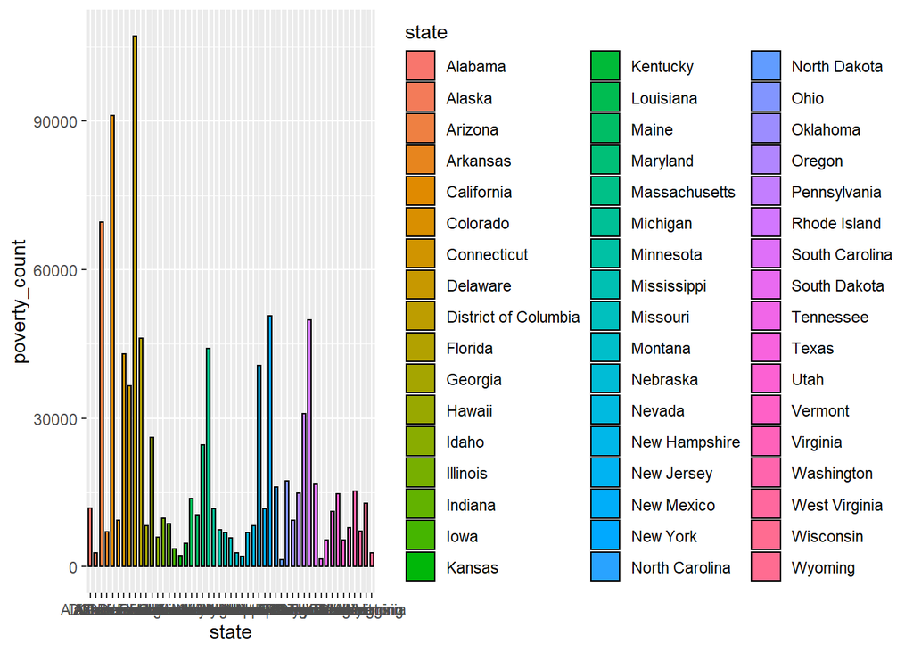

```r
library(ggplot2)

ggplot(by_state, aes(fill=state, y=poverty_count, x=state)) +
  geom_bar(position='dodge', stat='identity',
           color = "black", width = 0.60)
```

### To find which state exactly has the highest poverty_count in the above barplot since the sate is not detectable easily It shows District of Columbia has the highest poverty count

```r
by_state %>% slice(which.max(poverty_count))
```

```
## # A tibble: 1 x 5
##   state               population per_capita_inco~ poverty_count bachelors_degree
##   <chr>                    <dbl>            <dbl>         <dbl>            <dbl>
## 1 District of Columb~     692683            56147        107140           289259
```

### Now repeat the above graph for education

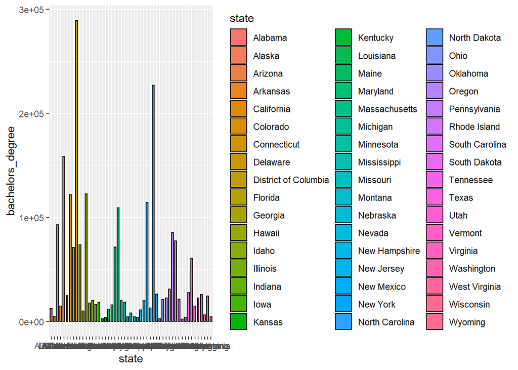

```r
library(ggplot2)

ggplot(by_state, aes(fill=state, y=bachelors_degree, x=state)) +
  geom_bar(position='dodge', stat='identity',
           color = "black", width = 0.60)
```

### To find which state exactly has the highest education average in the above barplot since the sate is not detectable easily It shows District of Columbia also has the highest bachelors_degree average

```r
by_state %>% slice(which.max(bachelors_degree))
```

```
## # A tibble: 1 x 5
##   state               population per_capita_inco~ poverty_count bachelors_degree
##   <chr>                    <dbl>            <dbl>         <dbl>            <dbl>
## 1 District of Columb~     692683            56147        107140           289259
```

### We can clearly see that there is a maximum increase for poverty and education for the state of District of Columbia

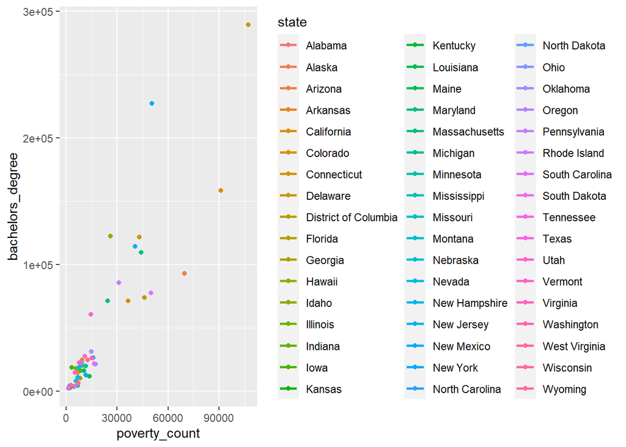

```r
# We can that

by_state %>%
  ggplot(aes(x=poverty_count,
             y=bachelors_degree,
             color=state))+
  geom_point()+
  geom_smooth(method="lm",se = FALSE)
```

```r
ggsave("add_regression_line_per_state_to_scatterplot_ggplot2.png")
```